# Tarea 4: Estadística de Áreas

Pedro Montenegro

23/11/2019

# 1 Introducción

El tutorial fue preparado para los estudiantes graduados en la novena cumbre de Midwest sobre economía aplicada, regional y estudios urbanos (AERUS) en Abril 23-24 de 2016 para la Universidad de Illinois en Champaign urbana.

Estas notas ilustran el uso de r en análisis econometrico espacial. La teoría es basada en Anselin y Bera (1998) y Arbia (2014) y los aspectos prácticos son actualización de versión de Anselin (2003), con algunos adiciones en visualización espacial para datos r.

Comentarios y sugerencias son siempre bienvenidas y se pueden enviar a srmntbr2@illinois.edu1.

# 2 ¿Qué es r y por qué usalo?

R es un software libre, código abierto, y lenguaje orientado a objetos. Libre y código abierto significa que cualquiera puede usarlo, redistribuir y cambiar el software de cualquier forma. Sin embargo, “R es un sofware libre con entorno computacional estadístico y gráficos. Esto compila y corre una amplia variedad de plataformas UNIX, windows y MacOS.” [Aquí](http://cran.r-project.org)

Existen muchos software externos que hacen el análisis de datos bonitos y parecen más fáciles que r, entonces porque debería invertir en apreder sobre R?. Existen en mi opinión al menos tres caracteristicas que R hacen que r valga la pena aprenderlo. Primero que todo, es gratis. Muchos software hoy en día son caros, pero r es gratis y siempre lo será. R también es un lenguaje, lo que significa que no solo puedes usar funciones que estén construidas en el software, sino que también puedes crear tus propias funciones (para conocer el poder del lenguaje R puede echar un vistazo al Paquete de Regresión Cuantil del Profesor Koenker). La última razón es que R está extremadamente bien soportado. Si tiene una pregunta solamente puede buscarla en Google, publicarla en StackOverflow o usar R-blogger. Si aún no está convencido, simplemente puede escribir “por qué usar el lenguaje R” en Google y creo que los resultados hablarán por sí mismos.

Todas estas características más el hecho de que los investigadores en la frontera de la profesión usan R como parte de su investigación hace de R una gran herramienta para el análisis de datos espaciales.

# 3 Introducción al análisis espacial en R

## 3.1 Motivación para el uso de análisis espacial

Probablemente el argumento más importante a tomar en un enfoque espacial es el supuesto de independencia entre observaciones ya no es válido. Atributos de observación $i$ pueden influir en los atributos de observación $j$.

Para ilustrar un conjunto de datos muy pequeño de lo que se puede lograr en R para el análisis espacial, nuestro ejemplo examinará crímenes violentas y ejecuciones hipotecarias en la ciudad de Chicago. Los datos de delitos, así como tractos de los archivos shapefile usados aquí provienen del Portal de Datos de Chicago, mientras que los datos de ejecuciones hipotecarias provienen del Departamento de Vivienda y Desarrollo Urbano de los EE.UU (HUD), estos están disponibles al público.

## 3.2 Paquetes de R para el análisis de datos espaciales.

En R, la unidad fundamental de compartie código es el paquete (package). Un paquete agrupa código, datos, documentación, pruebas y es fácil de compartir con otros. A partir de abril de 2016, había más de 8,200 paquetes disponibles en la Red de Archivos R, conocida como **CRAN**, la repositorio público para paquetes R. Esta gran variedad de paquetes es una de las razones por las que R tiene tanto éxito: lo más probable es que alguien ya haya resuelto un problema en el que estás trabajando, y puedes beneficiarte de su trabajo descargando su paquete. (Wickham (2015))

Hoy nos enfocamos en tres paquetes **maptools** (R. Bivand y Lewin Koh (2016)), **spdep** (R. Bivand y Piras (2015), R. Bivand, Hauke y Kossowski (2013)) y **leaflet** (Cheng y Xie (2015)) y un cuarto, el paquete **RColorBrewer** (Neuwirth (2014)) para hacer nuestros gráficos más atractivas.

## 3.3 Leyendo y Gráficando datos espaciales en R.

Los datos espaciales vienen en muchas “formas” y “tamaños”, los tipos más comunes de datos espaciales son:

Los puntos son la forma más básica de datos espaciales. Denota una ubicación de un solo punto, como ciudades, una lectura de GPS o cualquier otro objeto discreto definido en el espacio.

Las líneas son un conjunto de puntos ordenados, conectados por segmentos de línea recta. Los polígonos denotan un área, y pueden pensarse como una secuencia de puntos conectados, donde el primer punto es el mismo que la última Cuadrícula (Ráster) es una colección de puntos o rectangular células, organizadas en una red regular

Para más detalles, ver R. S. Bivand, Pebesma y Gomez-Rubio (2008). Hoy nos centraremos en los polígonos. Los datos espaciales generalmente vienen en forma de archivo. Este tipo de archivos almacena información de geometría y atributos no topológicos para las características espaciales en un conjunto de datos.

Además, no requieren mucho espacio en disco y son fáciles de leer y escribir. (ESRI (1998))

Primero tenemos que descargar y guardar los archivos en nuestra computadora desde nuestro servidor en [Ejecuciones Hipotecarias](http://www.econ.uiuc.edu/~lab/workshop/foreclosures/). Guardé en Mi Escritorio.

- **Archivo principal:** foreclosures.shp
- **Archivo de índice:** foreclosures.shx
- **Tabla + dBASE:** ejecuciones hipotecarias.dbf

El archivo principal describe una forma con una lista de sus vértices. En el archivo de índice, cada registro contiene el desplazamiento del registro del archivo principal correspondiente desde el comienzo del archivo principal. La tabla dBASE contiene atributos de características con un registro por característica. (ESRI (1998))

Para leer datos de un archivo de forma de polígono en R, utilizamos la función **readShapePoly()** que creará un objeto SpatialPolygonsDataFrame. Para obtener más información sobre la función, el comando ?ReadShapePoly le dará acceso al archivo de ayuda.

Pero antes de leer en el shapefile primero configuramos nuestro directorio de trabajo. R siempre apunta a un directorio en su computadora, para encontrar cuál usa **getwd()** (obtener el directorio de trabajo).

El archivo shapefile ahora lee y almacena en un objeto llamado $chi.poly$. Para verificar que es un SpatialPolygonsDataFrame, podemos usar la función **class()**

| Objeto |
| --- |
| SpatialPolygonsDataFrame |

Un objeto SpatialPolygonsDataFrame reúne las representaciones espaciales de los polígonos con datos. Las etiquetas de identificación de los polígonos en la ranura coinciden con los nombres de fila del marco de datos para asegurarse de que las filas de datos correctas estén asociadas con el objeto espacial correcto. (R. S. Bivand, Pebesma y Gómez-Rubio (2008))

Este objeto tiene cuatro partes o ranuras: la primera es la ranura de datos que contiene las variables que se utilizarán para nuestro análisis; el segundo es la ranura del polígono y contiene la información shapefile. El tercer espacio, bbox, es el cuadro delimitador dibujado alrededor de los límites y el cuarto espacio es la cadena proj4 que contiene las proyecciones. Para acceder a la ranura de datos podemos usar la función de ranura o el símbolo @. Para una apariencia compacta de la ranura de datos, podemos usar la función str:

```
## 'data.frame':    897 obs. of  16 variables:
##  $ SP_ID     : Factor w/ 897 levels "1","10","100",..: 1 112 223 334 445 556 667 778 887 2 ...
##  $ fips      : Factor w/ 897 levels "17031010100",..: 1 2 3 4 5 6 7 8 9 10 ...
##  $ est_fcs   : int  43 129 55 21 64 56 107 43 7 51 ...
##  $ est_mtgs  : int  904 2122 1151 574 1427 1241 1959 830 208 928 ...
##  $ est_fcs_rt: num  4.76 6.08 4.78 3.66 4.48 4.51 5.46 5.18 3.37 5.5 ...
##  $ res_addr  : int  2530 3947 3204 2306 5485 2994 3701 1694 443 1552 ...
##  $ est_90d_va: num  12.61 12.36 10.46 5.03 8.44 ...
##  $ bls_unemp : num  8.16 8.16 8.16 8.16 8.16 8.16 8.16 8.16 8.16 8.16 ...
##  $ county    : Factor w/ 1 level "Cook County": 1 1 1 1 1 1 1 1 1 1 ...
##  $ fips_num  : num  1.7e+10 1.7e+10 1.7e+10 1.7e+10 1.7e+10 ...
##  $ totpop    : int  5391 10706 6649 5325 10944 7178 10799 5403 1089 3634 ...
##  $ tothu     : int  2557 3981 3281 2464 5843 3136 3875 1768 453 1555 ...
##  $ huage     : int  61 53 56 60 54 58 48 57 61 48 ...
##  $ oomedval  : int  169900 147000 119800 151500 143600 145900 153400 170500 215900 114700 ...
##  $ property  : num  646 914 478 509 641 612 678 332 147 351 ...
##  $ violent   : num  433 421 235 159 240 266 272 146 78 84 ...
##  - attr(*, "data_types")= chr  "C" "C" "N" "N" ...
```

La primera parte es la parte marco de datos que contiene los datos para nuestro análisis. Podemos ver las variables contenidas en la porción de datos del archivo, incluyendo:

- **est_fcs:** el recuento estimado de ejecuciones hipotecarias comienza desde enero de 2007 hasta junio de 2008
- **est_mtgs:** número estimado de hipotecas activas desde enero de 2007 hasta junio de 2008
- **est_fcs_rt:** número de ejecuciones hipotecarias iniciadas dividido por número de hipotecas multiplicado por 100
- **bls_unemp:** lugar de junio de 2008 o tasa de desempleo del condado
- **totpop:** población total del Censo 2000
- **violento:** número de delitos violentos denunciados entre enero de 2007 y diciembre de 2008
- **propiedad:** número de delitos contra la propiedad denunciados entre enero de 2007 y diciembre de 2008

También podemos obtener estadísticas resumen de las variables de interés utilizando el resumen de funciones. Por ejemplo:

| Estadísticas Resumen minimum | Estadísticas Resumen q1 | Estadísticas Resumen median | Estadísticas Resumen mean | Estadísticas Resumen q3 | Estadísticas Resumen maximum |
| --- | --- | --- | --- | --- | --- |
| 0 | 49 | 103 | 169,3389 | 226 | 1.521 |

Aquí accedimos a la porción de datos del shapefile con el signo @ y luego a la variable con el signo $. Para ver las otras ranuras, podemos proceder de la misma manera.

Una buena característica de la clase de objetos espaciales es que podemos usar las características de gráficos tradicionales de R. El siguiente comando nos proporciona un gráfico de las secciones censales de Chicago:

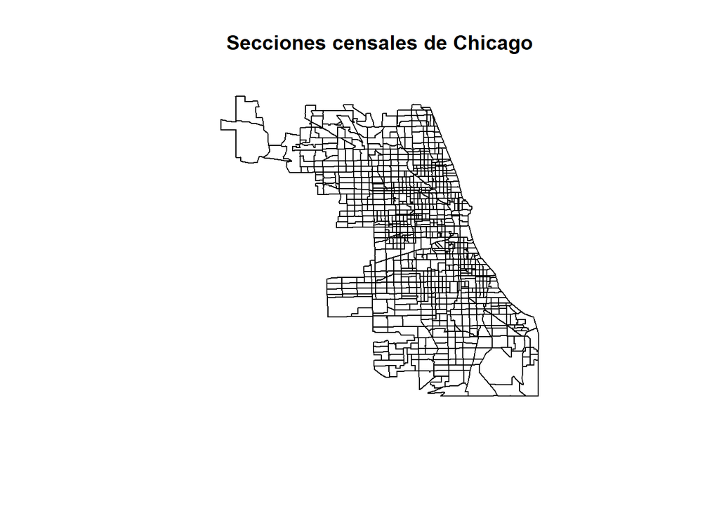

pero podemos ir un paso más allá y hacer mejores parcelas usando el paquete de folleto. Esto genera un mapa interactivo que se puede representar en páginas HTML.

[interactive chart not shown]

Podemos agredar color usando el paquete RColorBrewer

[interactive chart not shown]

La función colorQuantile del paquete **leaflet** mapea los valores de los datos a colores siguiendo una paleta. En este caso, he especificado una paleta de Naranjas y Rojos, para más paletas puede acceder al archivo de ayuda de RColorBrewer:? **RColorBrewer**.

# 4 Econometría espacial en R

Cuando se trata del espacio, uno debe tener en cuenta la primera ley de geografía de Tobler “Todo está relacionado con todo lo demás, pero las cosas cercanas están más relacionadas que las que están muy separadas” (Tobler (1979)).

En esta sección nos centraremos en la especificación de la dependencia espacial, en las pruebas de especificación para detectar la dependencia espacial en los modelos de regresión y en los modelos de regresión básicos que incorporan la dependencia espacial. Ilustraremos esto utilizando los datos en el archivo de forma cargado en la sección anterior.

## Mínimos cuadrados ordinales (OLS)

El enfoque tradicional durante muchos años ha sido ignorar la dependencia espacial de los datos y simplemente ejecutar una regresión OLS.

$y=Xβ+ϵ$

En R esto se logra con la función $lm$, por ejemplo:

```r
chi.ols<-lm(violent~est_fcs_rt+bls_unemp, data=chi.poly@data)
```

He especificado el “modelo” como $violento$ ~ est_fcs_rt + bls_unemp donde la variable dependiente es violento, **est_fcs_rt** y **bls_unemp** son las variables explicativas. También he especificado el conjunto de datos que son los datos de la ranura de nuestro archivo shapefile. Tenga en cuenta que para acceder a este espacio utilizo el símbolo @. Esta línea no devuelve nada porque hemos creado un objeto lm que llamé chi.ols. Para ver los resultados, utilizamos la función de **summary()**.

| Modelo violento ~ est_fcs_rt + bls_unemp Terminos | Modelo violento ~ est_fcs_rt + bls_unemp Coeficientes | Modelo violento ~ est_fcs_rt + bls_unemp std.error | Modelo violento ~ est_fcs_rt + bls_unemp statistic | Modelo violento ~ est_fcs_rt + bls_unemp p.value |
| --- | --- | --- | --- | --- |
| (Intercept) | -18,6271608 | 45,366383 | -0,4105939 | 0,6814687 |
| est_fcs_rt | 28,2976837 | 1,434946 | 19,7203846 | 0,0000000 |
| bls_unemp | -0,3080287 | 5,770304 | -0,0533817 | 0,9574397 |

El problema de ignorar la estructura espacial de los datos implica que las estimaciones de OLS en el modelo no espacial pueden ser sesgadas, inconsistentes o ineficientes, dependiendo de cuál sea la verdadera dependencia subyacente (para más información, ver Anselin y Bera (1998)).

## 4.2 Modelado de la dependencia espacial

Ahora echamos un vistazo más de cerca a la dependencia espacial, o para ser más precisos sobre su autocorrelación espacial de expresión más débil. La autocorrelación espacial mide el grado en que un fenómeno de interés se correlaciona consigo mismo en el espacio (Cliff y Ord (1973)). En otras palabras, valores similares aparecen cerca uno del otro, o agrupados, en el espacio (autocorrelación espacial positiva) o los valores vecinos son diferentes (autocorrelación espacial negativa). La autocorrelación espacial nula indica que el patrón espacial es aleatorio. Siguiendo a Anselin y Bera (1998) podemos expresar la existencia de autocorrelación espacial con la siguiente condición de momento:

$Cov(yi,yj)≠0fori≠j$

donde $ yi $ y $ yj $ son observaciones en una variable aleatoria en las ubicaciones i y j. El problema aquí es que necesitamos estimar los términos de covarianza de $ N $ por $ N $ directamente para las observaciones de $ N $. Para superar este problema, imponemos restricciones a la naturaleza de las interacciones. Un tipo de restricción es definir para cada punto de datos un “conjunto de vecindad” relevante. En la econometría espacial, esto se operacionaliza a través de la matriz de ponderaciones espaciales. La matriz generalmente denotada por $ W $ es un $ N $ por $ N $ matriz positiva y simétrica que denota por cada observación (fila) aquellas ubicaciones (columnas) que pertenecen a su conjunto de vecindarios como elementos distintos de cero (Anselin y Bera (1998), Arbia (2014)), el elemento típico es entonces:

$ N (i) $ es el conjunto de vecinos de la ubicación j. Por convención, los elementos diagonales se establecen en cero, es decir, $ wii = 0 $. Para ayudar con la interpretación, la matriz a menudo está estandarizada por filas, de modo que los elementos de una fila dada se suman a una.

La especificación del conjunto vecino es bastante arbitraria y hay una amplia gama de sugerencias en la literatura. Una forma popular es usar uno de los dos criterios siguientes:

- Criterio de torre: dos unidades están cerca una de la otra si comparten un lado
- Criterio reina: dos unidades están cerca si comparten un lado o una arista.

Otro enfoque utilizado es denotar dos observaciones como vecinas si están dentro de una cierta distancia, es decir, j∈N (j) si dij <dmax donde d es la distancia entre la ubicación i y j.

Aquí nos centraremos en usar el criterio de reina y alentamos al lector a experimentar con el criterio de torre. En R para obtener la matriz de pesos, utilizamos dos funciones. En el primer paso usamos **poly2nb** que construye una lista de vecinos, si se especifica la opción queen = TRUE, se construirá utilizando el criterio queen. Si se especifica FALSO, se utilizarán los criterios de torre. El siguiente paso es complementar la lista de vecinos con los pesos espaciales. La opción fila W estandariza la matriz.

```
## Characteristics of weights list object:
## Neighbour list object:
## Number of regions: 897
## Number of nonzero links: 6140
## Percentage nonzero weights: 0.7631036
## Average number of links: 6.845039
##
## Weights style: W
## Weights constants summary:
##     n     nn  S0       S1       S2
## W 897 804609 897 274.4893 3640.864
```

Podemos gráficar la distribución link con la usual función **plot()**

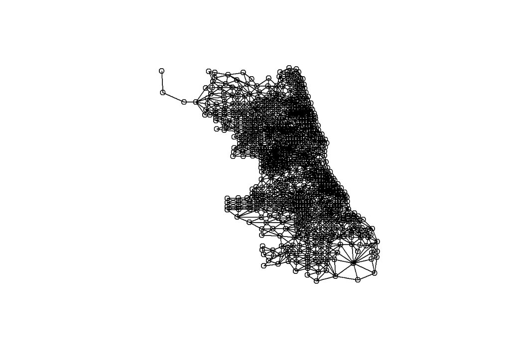

Para obtener la matriz de peso basada en distancias, usamos dos funciones: coordenadas que recuperarán las coordenadas centroides de los polígonos de las segmentos censales y datos cercanos que identificarán vecinos entre dos distancias en kilómetros medidos usando la distancia euclidiana. Por ejemplo, para encontrar vecinos dentro de 1 kilómetro hacemos:

```r
coords<-coordinates(chi.poly)
W_dist<-dnearneigh(coords,0,1,longlat = FALSE)
```

Le animo a comparar las distribuciones de enlaces para estas tres formas de definir vecinos.

## 4.2.1 Modelos espaciales autorregresivo (SAR)

La dependencia del rezago espacial en la definición de regresión puede modelarse de manera similar a un proceso autorregresivo en series de tiempo. Formalmente,

$y=ρWy+Xβ+ϵ$

La presencia del término Wy induce una correlación distinta de cero con el término de error, similar a la presencia de una variable endógena, pero diferente del contexto de series de tiempo. Contrariamente a las series de tiempo, $[Wy]i$ siempre está correlacionado con $ϵi$ independientemente de la estructura de los errores. Esto implica que las estimaciones de OLS en el modelo no espacial serán sesgadas e inconsistentes. (Anselin y Bera (1998))

## 4.2.2 Modelos errores espaciales (SEM)

Otra forma de modelar la autocorrelación espacial en un modelo de regresión es especificar el proceso autorregresivo en el término de error:

$y=Xβ+ϵ$

con

$ϵ=λWϵ+u$

Si esta es la forma “verdadera” de dependencia espacial, las estimaciones de OLS serán insesgadas pero ineficientes.

## 4.3 Pruebas de autocorrelación Espacial

Existen múltiples pruebas para probar la presencia de autocorrelación espacial.

En esta nota, nos enfocamos en un conjunto restringido: la prueba de Moran I y las pruebas de multiplicador de la Lagrange.

## 4.3.1 Prueba I de Moran

La prueba I de Moran se desarrolló originalmente como un análogo bidimensional de la prueba de Durbin-Watson

$I=(e′Wee′e)$

donde $e=y−Xβ$ es un vector de residuos OLS $β=(X′X)−1X′y$, W es la matriz de pesos espaciales estandarizadas de las filas. (Para más detalles ver Anselin y Bera (1998))

Para realizar una prueba de Moran en nuestros datos, necesitamos dos entradas, un objeto de regresión lm (estimado en la sección OLS) y la matriz de peso espacial

| Global Moran I con regresión residuos Observado_Moran | Global Moran I con regresión residuos Expectativa | Global Moran I con regresión residuos Varianza | Global Moran I con regresión residuos statistic | Global Moran I con regresión residuos p.value |
| --- | --- | --- | --- | --- |
| 0,2142252 | -0,0020099 | 0,0003367 | 11,78494 | 4,667472e-32 |

El cálculo de la estadística es relativo a una elección dada de los pesos espaciales W. Las diferentes especificaciones de la matriz de pesos darán resultados diferentes. Animo al lector a probar esto con el criterio de torre.

## 4.3.2 Prueba Multiplicador de Lagrange

Una buena característica de la prueba I de Moran es que tengo un alto poder frente a una amplia gama de alternativas (Anselin y Bera (1998)). Sin embargo, no nos guía en la selección de modelos alternativos. Por otro lado, la prueba del multiplicador de Lagrange especifica la hipótesis alternativa que nos ayudará con la tarea. Las pruebas de LM para la dependencia espacial se incluyen en la función **lm.LMtests** e incluyen como alternativas la presencia de un retraso espacial y la presencia de un retraso espacial en el término de error. Ambas pruebas, así como sus formas robustas, están incluidas en la función lm.LMtests(). Para llamarlos usamos la opción **test = “all”**. Nuevamente, un objeto de regresión y un objeto espacial listw deben pasarse como argumentos:

| Diagnostico de dependencia espacial LMerr statistic | Diagnostico de dependencia espacial LMerr p.value | Diagnostico de dependencia espacial LMerr parameter |
| --- | --- | --- |
| 134,5243 | 0 | 1 |

| Diagnostico de dependencia espacial LMlag statistic | Diagnostico de dependencia espacial LMlag p.value | Diagnostico de dependencia espacial LMlag parameter |
| --- | --- | --- |
| 182,1762 | 0 | 1 |

| Diagnostico de dependencia espacial RLMerr statistic | Diagnostico de dependencia espacial RLMerr p.value | Diagnostico de dependencia espacial RLMerr parameter |
| --- | --- | --- |
| 0,0006676 | 0,9793863 | 1 |

| Diagnostico de dependencia espacial RLMlag statistic | Diagnostico de dependencia espacial RLMlag p.value | Diagnostico de dependencia espacial RLMlag parameter |
| --- | --- | --- |
| 47,65255 | 0 | 1 |

| Diagnostico de dependencia espacial SARMA statistic | Diagnostico de dependencia espacial SARMA p.value | Diagnostico de dependencia espacial SARMA parameter |
| --- | --- | --- |
| 182,1768 | 0 | 2 |

Dado que LMerr y LMlag son estadísticamente significativos diferentes de cero, debemos analizar sus contrapartes robustas. Estas contrapartes robustas son realmente robustas a la presencia del otro “tipo” de autocorrelación. La versión robusta de las pruebas sugiere que el rezago del modelo es la alternativa más probable.

## 4.4 Ejecución de regresiones espaciales

### 4.4.1 Modelos SAR

La estimación del modelo SAR puede abordar en:

```
##
## Call:
## lagsarlm(formula = violent ~ est_fcs_rt + bls_unemp, data = chi.poly@data,
##     listw = W)
##
## Residuals:
##      Min       1Q   Median       3Q      Max
## -519.127  -65.003  -15.226   36.423 1184.193
##
## Type: lag
## Coefficients: (asymptotic standard errors)
##             Estimate Std. Error z value Pr(>|z|)
## (Intercept) -93.7885    41.3162  -2.270  0.02321
## est_fcs_rt   15.6822     1.5600  10.053  < 2e-16
## bls_unemp     8.8949     5.2447   1.696  0.08989
##
## Rho: 0.49037, LR test value: 141.33, p-value: < 2.22e-16
## Asymptotic standard error: 0.039524
##     z-value: 12.407, p-value: < 2.22e-16
## Wald statistic: 153.93, p-value: < 2.22e-16
##
## Log likelihood: -5738.047 for lag model
## ML residual variance (sigma squared): 20200, (sigma: 142.13)
## Number of observations: 897
## Number of parameters estimated: 5
## AIC: 11486, (AIC for lm: 11625)
## LM test for residual autocorrelation
## test value: 8.1464, p-value: 0.0043146
```

Otro camino es usar $2SLS$ usando la función stsls. Le dejo esto al lector para que pueda comparar los resultados con el enfoque MLE. La función es:

```
##
## Call:
## stsls(formula = violent ~ est_fcs_rt + bls_unemp, data = chi.poly@data,
##     listw = W)
##
## Residuals:
##      Min       1Q   Median       3Q      Max
## -472.703  -61.955  -12.668   36.795 1168.899
##
## Coefficients:
##                Estimate  Std. Error t value  Pr(>|t|)
## Rho            0.629161    0.082777  7.6007 2.953e-14
## (Intercept) -115.062608   42.648091 -2.6980  0.006977
## est_fcs_rt    12.111383    2.488729  4.8665 1.136e-06
## bls_unemp     11.499706    5.406927  2.1268  0.033433
##
## Residual variance (sigma squared): 19943, (sigma: 141.22)
```

En este paso, crearé una nueva variable en la porción de datos del archivo de shapefile que ayudará a trazar los residuos. Para trazar los residuos, uso la función spplot en el paquete **spdep**. Los argumentos son el archivo de forma, la variable que queremos trazar, el número de saltos y los colores que vamos a utilizar. Para especificar los colores, utilizamos la paleta Rojo y Azul (RdBu) del paquete RColorBrewer.

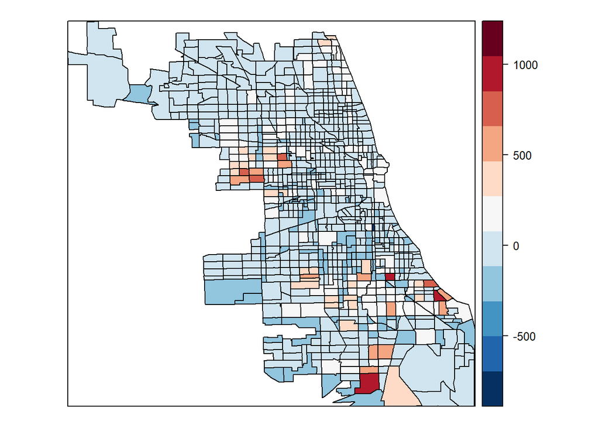

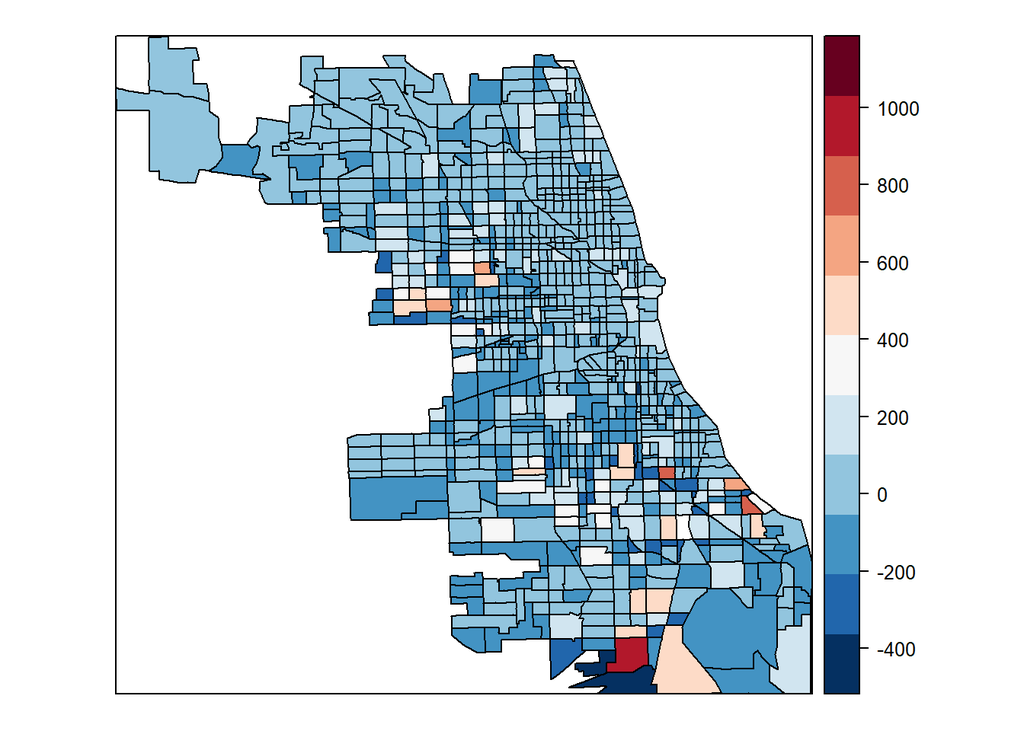

### 4.4.1.1 Efectos Marginales

Tenga en cuenta que la presencia de la matriz de pesos espaciales hace que los efectos marginales sean más ricos y un poco más complicados que en el modelo OLS “tradicional”. Tendremos tres medidas de impacto sugeridas por Pace y LeSage (2009) y se realiza en R con los impactos de la función

```
## Impact measures (lag, exact):
##               Direct  Indirect    Total
## est_fcs_rt 16.434479 14.336896 30.77137
## bls_unemp   9.321585  8.131842 17.45343
```

El impacto directo se refiere al impacto total promedio de un cambio de una variable independiente en el dependiente de cada observación, es decir, $ n − 1∑ni = 1∂E (yi) ∂Xi $, el impacto indirecto que es la suma de impacto producido en una sola observación por todas las demás observaciones y el impacto de una observación en todas las demás. El total es la suma de los dos.

### 4.4.2 SEM Models

Por otro lado, si queremos estimar el modelo de error espacial, tenemos dos enfoques nuevamente. Primero, podemos usar la máxima verosimilitud como antes, con la función **errorsarlm**

```
##
## Call:
## errorsarlm(formula = violent ~ est_fcs_rt + bls_unemp, data = chi.poly@data,
##     listw = W)
##
## Residuals:
##      Min       1Q   Median       3Q      Max
## -650.506  -64.355  -22.646   35.461 1206.346
##
## Type: error
## Coefficients: (asymptotic standard errors)
##             Estimate Std. Error z value Pr(>|z|)
## (Intercept)  -1.2624    43.0509 -0.0293   0.9766
## est_fcs_rt   19.4620     1.9450 10.0062   <2e-16
## bls_unemp     4.0380     5.5134  0.7324   0.4639
##
## Lambda: 0.52056, LR test value: 109.68, p-value: < 2.22e-16
## Asymptotic standard error: 0.042291
##     z-value: 12.309, p-value: < 2.22e-16
## Wald statistic: 151.51, p-value: < 2.22e-16
##
## Log likelihood: -5753.875 for error model
## ML residual variance (sigma squared): 20796, (sigma: 144.21)
## Number of observations: 897
## Number of parameters estimated: 5
## AIC: 11518, (AIC for lm: 11625)
```

El mismo gráfico para los residuos SEM se puede hacer como antes y se deja para el lector. Un segundo enfoque es utilizar mínimos cuadrados generalizados factibles (GLS) con la función GMerrorsar. La función es:

```
##
## Call:
## GMerrorsar(formula = violent ~ est_fcs_rt + bls_unemp, data = chi.poly@data,
##     listw = W)
##
## Residuals:
##      Min       1Q   Median       3Q      Max
## -697.623  -76.205  -33.292   44.053 1271.737
##
## Type: GM SAR estimator
## Coefficients: (GM standard errors)
##             Estimate Std. Error z value Pr(>|z|)
## (Intercept)  -1.8587    43.5671 -0.0427   0.9660
## est_fcs_rt   21.1757     1.8752 11.2925   <2e-16
## bls_unemp     2.9037     5.5869  0.5197   0.6032
##
## Lambda: 0.44789 (standard error): 0.11067 (z-value): 4.0473
## Residual variance (sigma squared): 21515, (sigma: 146.68)
## GM argmin sigma squared: 21607
## Number of observations: 897
## Number of parameters estimated: 5
```

# Referencias

Anselin, Luc. 2003. “An Introduction to Spatial Regression Analysis in R.” Available at: Aquí

Anselin, Luc, and Anil K Bera. 1998. “Spatial Dependence in Linear Regression Models with an Introduction to Spatial Econometrics.” Statistics Textbooks and Monographs 155. MARCEL DEKKER AG: 237–90.

Arbia, Giuseppe. 2014. A Primer for Spatial Econometrics: With Applications in R. Palgrave Macmillan.

Bivand, Roger S, Edzer J Pebesma, and Virgilio Gomez-Rubio. 2008. Applied Spatial Data Analysis with R. Springer. Springer.

Bivand, Roger, and Nicholas Lewin-Koh. 2016. Maptools: Tools for Reading and Handling Spatial Objects. [Aquí](https://CRAN.R-project.org/package=maptools.)

Bivand, Roger, and Gianfranco Piras. 2015. “Comparing Implementations of Estimation Methods for Spatial Econometrics.” Journal of Statistical Software 63 (18): 1–36. [Aquí](http://www.jstatsoft.org/v63/i18/.)

Bivand, Roger, Jan Hauke, and Tomasz Kossowski. 2013. “Computing the Jacobian in Gaussian Spatial Autoregressive Models: An Illustrated Comparison of Available Methods.” Geographical Analysis 45 (2): 150–79. [Aquí](http://www.jstatsoft.org/v63/i18/.)

Cheng, Joe, and Yihui Xie. 2015. Leaflet: Create Interactive Web Maps with the JavaScript ’Leaflet’ Library. [Aquí](http://rstudio.github.io/leaflet/.)

Cliff, Andrew David, and J Keith Ord. 1973. Spatial Autocorrelation. Vol. 5. Pion London.

ESRI, Environmental Systems Research Institute. 1998. “ESRI Shapefile Technical Description.” Disponible

Neuwirth, Erich. 2014. RColorBrewer: ColorBrewer Palettes. [Aquí](https://CRAN.R-project.org/package=RColorBrewer.)

Pace, R Kelley, and JP LeSage. 2009. “Introduction to Spatial Econometrics.” Boca Raton, FL: Chapman &Hall/CRC.

Tobler, WR. 1979. “Cellular Geography.” In Philosophy in Geography, 379–86. Springer.

Wickham, Hadley. 2015. R Packages. “O’Reilly Media, Inc.”